# Final project - Open Science Practices In Remote Sensing

# Introduction to Sourcetree and Pickle

# [Sourcetree](https://www.sourcetreeapp.com/)

Sourcetree is a free Git and Mercurial desktop client, developed by Atlassian, which provides a graphical user interface (GUI) for managing and interacting with version control repositories.

With Sourcetree, users can easily clone, create, and manage Git and Mercurial repositories. It simplifies many complex version control tasks by providing an intuitive and user-friendly interface. Some of its key features include:

1. Repository Management.
2. Visual Branching and Merging.
3. Collaborative Workflows.
4. Commit History and Code Review
5. Etc.

### How does a GUI-Based git client help us to learn Git?

1. Visual Representation: A GUI-based Git client typically provides a visual representation of branches, commits, and other Git objects. This graphical representation can help users understand the underlying structure and history of a repository, making it easier to grasp concepts like branching, merging, and commit history.
2. Simplified Operations: GUI-based Git clients often simplify complex Git operations by providing buttons, menus, and other user-friendly controls. This can make it easier for beginners to perform common Git tasks, such as cloning repositories, creating branches, committing changes, merging branches, and resolving conflicts, without needing to memorize and type complex command-line commands.
3. Commit and Differences Visualization: GUI-based Git clients often provide visual diff tools that allow users to see the differences between different versions of files, highlighting additions, deletions, and modifications. This can help users understand the changes made in each commit and review code more easily.
4. Workflow Support: Many GUI-based Git clients offer support for popular Git workflows, such as Git Flow or feature branching. They may provide dedicated features and buttons to assist with these workflows, making it easier for beginners to follow best practices and learn about collaborative development processes.
5. Error Prevention and Guidance: GUI-based Git clients can help prevent common mistakes and provide guidance to users. For example, they may provide warnings before performing potentially destructive operations like force-pushing or deleting branches. They may also offer tooltips or explanations of Git concepts and commands, helping users understand the implications of their actions.
6. Integration with Hosting Services: GUI-based Git clients often integrate with popular hosting services like GitHub, GitLab, and Bitbucket. This integration allows users to easily browse repositories, create pull requests, and perform other collaborative actions without leaving the client. This exposure to Git workflows within a user-friendly interface can aid in learning how Git is used in real-world scenarios.

To download sourtree, click on the "Sourcetree" title. After that, link your git account (from gitlab, github, bitbucket, or others) to the software and once it is done, you will be ready to start!

For this project purposes, I have created a project on github called "Final_project_open_science" which we will clone from the remote repository to our local machine through Sourcetree.

First step - clone the repo: For this, we will use the HTTPS link provided by github/gitlab/bitbucket and paste it in a new tab on sourcetree. Moreover, we have to choose a folder destination where our local repository will be stored.

## Clone repo

[figure not shown]

First look from folder and Sourcetree: This is our local repository where I have started a jupyter notebook file called "Final_project.ipynb"

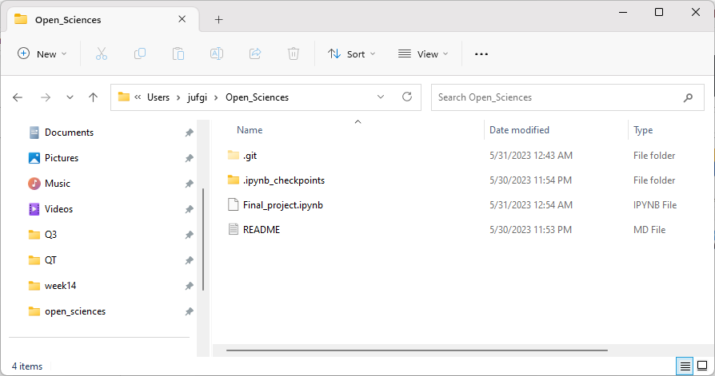

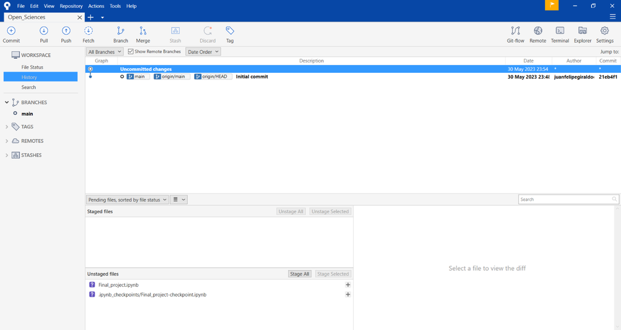

## Creating new branches

Creating new branches: Because I am used to work in a different branch besides "Main", I created a new branch called "Develop".

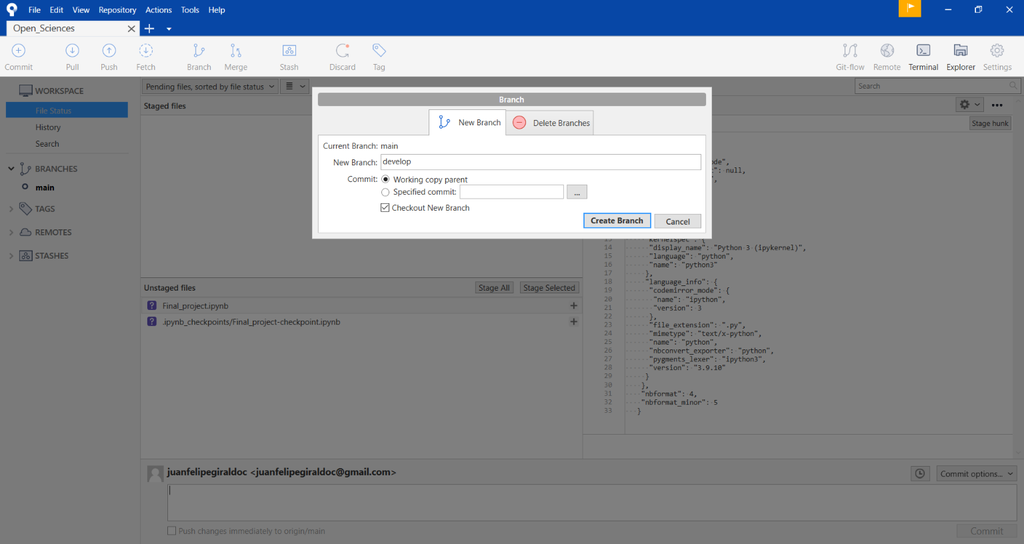

First commit from our new branch: Once we are ready to commit something, the "File Status" tab will report it and we can stage all the files, click on "Push changes immediately to -" to push the commit from the local repository to the remote repository, and finally, write something that respresents the changes and commit it!

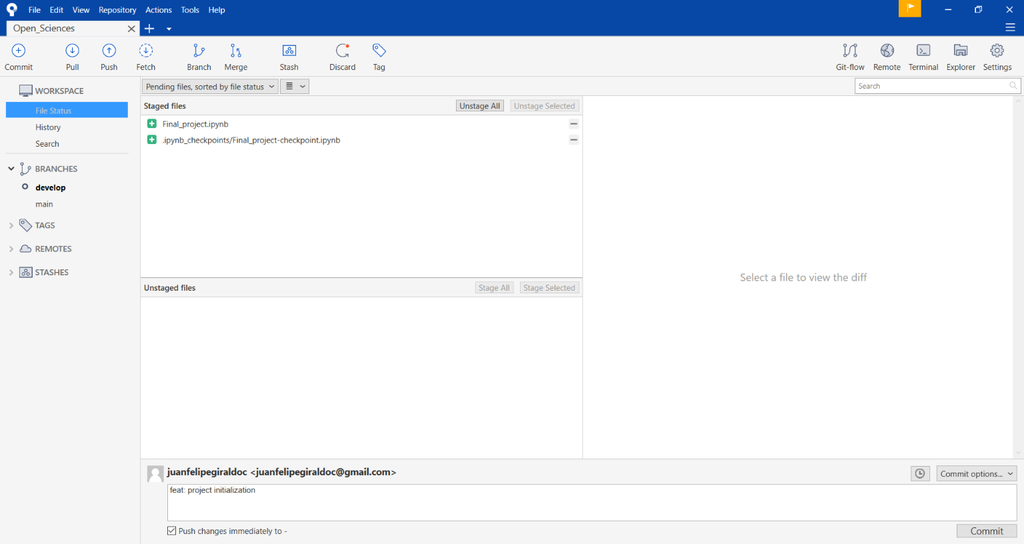

How does it look? So, now we can see our commit in our local/remote repository.

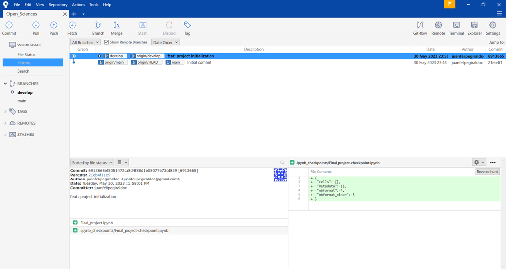

## Merge branches

All the attached screenshots and explanations were commit in a new branch called "Sourcetree" as you can see below.

[figure not shown]

I commit a last update in Sourcetree saying "feat: before merge branch from sourcetree to develop" in the Sourcetree branch.

Double click in the develop branch, to come back to develop.

[figure not shown]

Right click on the Sourcetree branch and select "Merge Sourcetree into current branch" to merge Sourcetree into develop.

[figure not shown]

Sourcetree will notify that there are some changes to push from the local repository to the remote repository.

[figure not shown]

Push the involved branches.

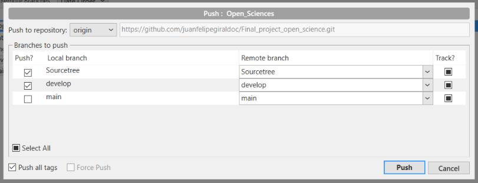

You can delete the previous branch. This is OPTIONAL.

[figure not shown]

This is how it looks now! Sourcetree is not there anymore and all the changes we made are into develop now.

[figure not shown]

# Pickle

In Python, "pickle" refers to a built-in module that provides a way to serialize (convert to a byte stream) and deserialize (reconstruct from a byte stream) Python objects. The process of converting objects into a byte stream is known as "pickling," and the reverse process is called "unpickling."

The pickle module is commonly used for tasks such as:

1. Object Serialization: Pickle allows you to convert complex Python objects, such as lists, dictionaries, classes, and instances, into a byte stream. This byte stream can be stored in a file or transmitted over a network.
2. Persistence: Pickling enables you to save the state of your program's objects to disk, allowing you to retrieve them later and resume execution from the saved state.
3. Data Exchange: Pickle can be used to exchange data between different Python programs or even different programming languages, as long as they have the ability to pickle and unpickle objects.

For showing pickle "in action" I will use the digits dataset provided by sklearn which contains images of all the digits (0-9) hand-written.

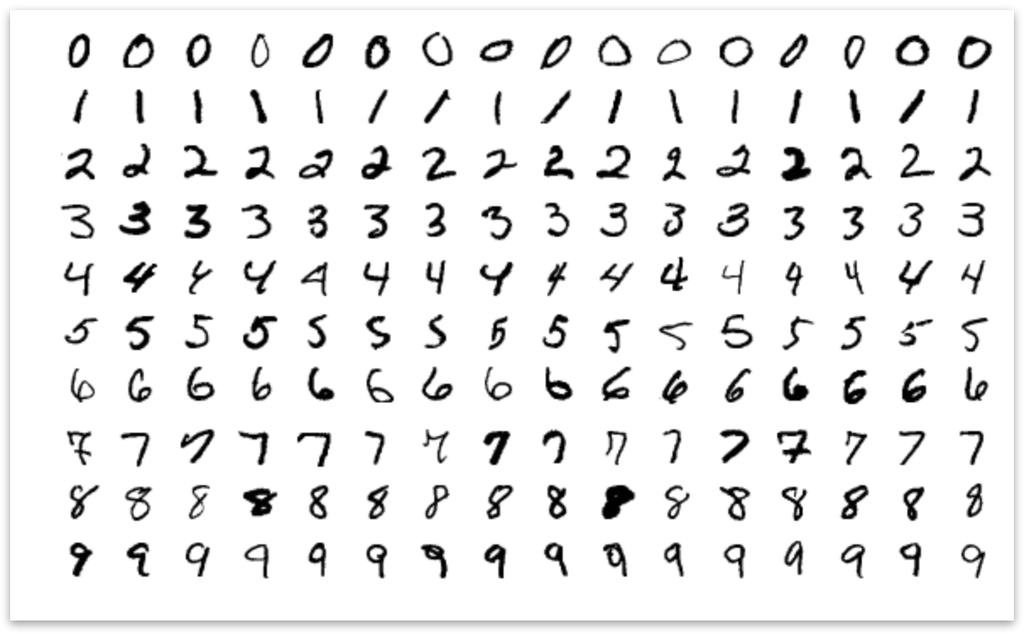

By [https://becominghuman.ai](https://becominghuman.ai/simple-neural-network-on-mnist-handwritten-digit-dataset-61e47702ed25). Accessed on May 31, 2023. Screenshot fair use.

Let's take a look at the dataset first to see if it makes sense:

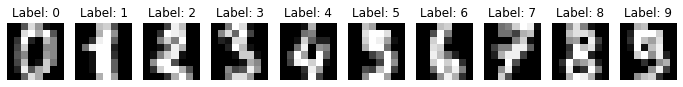

```python
import matplotlib.pyplot as plt
from sklearn import datasets

# Load the dataset
digits = datasets.load_digits()
x = digits.images
y = digits.target

# Display the images
num_images = 10
fig, axes = plt.subplots(1, num_images, figsize=(12, 6))

for i in range(num_images):
    axes[i].imshow(x[i], cmap='gray')
    axes[i].set_title("Label: {}".format(y[i]))
    axes[i].axis('off')

plt.show()
```

Previous code was made by ChatGPT.

```python
print(len(x))
print(len(y))
```

```
1797
1797
```

We can see that there are a total of 1797 data items in the dataset and 1797 labels, which means there are no NAN values to drop.

Let's use a logistic regressor to classify the images according to the labels.

```python
import pickle
from sklearn import datasets
from sklearn.model_selection import train_test_split
from sklearn.linear_model import LogisticRegression
from sklearn.metrics import accuracy_score

# Load the dataset
digits = datasets.load_digits()
X = digits.data
Y = digits.target

# Split the dataset into training and testing sets
X_train, X_test, y_train, y_test = train_test_split(X, Y, test_size=0.2, random_state=42)

# Train a logistic regression model
model = LogisticRegression(max_iter=1000, solver='sag')
model.fit(X_train, y_train)

# Make predictions on the test set
y_pred = model.predict(X_test)

# Calculate accuracy
accuracy = accuracy_score(y_test, y_pred)
print("Accuracy:", accuracy)
```

```
Accuracy: 0.9722222222222222
```

The accuracy seems ok. Now, it's time to serialize the model into a pickle! For this, we are going to save our -already trained- model into a file called "model.pickle":

```python
# Serialize the model using pickle
with open('model.pickle', 'wb') as f:
    pickle.dump(model, f)
```

It worked! Now we can deserialize it and see if it is still classifying properly:

```python
# Deserialize the model using pickle
with open('model.pickle', 'rb') as f:
    loaded_model = pickle.load(f)

# Make predictions using the deserialized model
new_predictions = loaded_model.predict(X_test)

# Calculate accuracy using the deserialized model
new_accuracy = accuracy_score(y_test, new_predictions)
print("Accuracy using deserialized model:", new_accuracy)
```

```
Accuracy using deserialized model: 0.9722222222222222
```

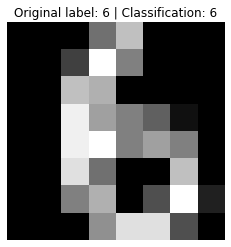

```python
Image_index = 0

imagen = X_test[Image_index]
Original_label = y_test[Image_index]
classified_label = new_predictions[Image_index]

plt.imshow(imagen.reshape(8, 8), cmap='gray')
plt.title("Original label: {} | Classification: {}".format(Original_label, classified_label))
plt.axis('off')
plt.show()
```

It worked!

## Additional Notes

**SourceTree** itself is not open-sourced however git is indeed. So, why am I introducing Sourcetree in an "Open Science" course?

1. Sourcetree as a GUI-based client help us to learn git by simplifying all the git commands in just some few clicks as it was showed in the Sourcetree section.
2. We can observe more clearly every change made by someone in the repository which means it simplifies collaborative projects.
3. This is a very useful tool in the industry but it is a good idea to learn how to use it from the academia.

**Pickle is not secure!**

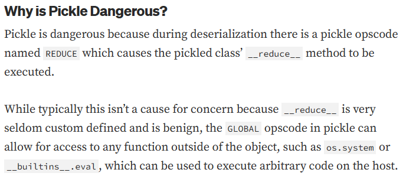

By [https://medium.com](https://medium.com/ochrona/python-pickle-is-notoriously-insecure-d6651f1974c9). Accessed on May 31, 2023. Screenshot fair use.

As [the article](https://medium.com/ochrona/python-pickle-is-notoriously-insecure-d6651f1974c9) explains, pickle is not safe. Packaging information with pickle can lead some people to hide line codes in the files which can be risky for our systems. However this is an usual risk we take when we share data/models/other files.

There are safer packaging protocols like json we can try, but we should research more about using json for model packaging.